# Impact of Severe Weather Events on Public Health and Economy in the United States

Karthik Arumugham

12 April 2016

## Synopsis

The U.S. National Oceanic and Atmospheric Administration’s (NOAA) storm database tracks characteristics of major storms and weather events in the United States, including when and where they occur, as well as estimates of any fatalities, injuries, crop and property damage. Preventing such outcomes to the extent possible is a key concern.

The objective of this project is to examine the impact of different weather events on public health and economy based on the storm data available from 1950 - 2011 and address the following two questions:

- Across the US, which types of events are most harmful with respect to population health?
- Across the US, which types of events have the greatest economic consequences?

Note:

- Damages data is NOT inflation adjusted.
- There are few mis-matches between the values of damage and the comments in REMARKS variable.

## Data Processing

**Loading necessary packages**

```r
library(knitr)
opts_chunk$set(echo = TRUE)
```

**Download and read the Dataset**

```r
if(!file.exists("repdata-data-StormData.csv.bz2")){download.file("http://d396qusza40orc.cloudfront.net/repdata%2Fdata%2FStormData.csv.bz2",destfile="repdata-data-StormData.csv.bz2")}
data <- read.csv("repdata-data-StormData.csv.bz2", header=TRUE)
```

Examine the dataset

```r
dim(data)
```

```
## [1] 902297     37
```

```r
names(data)
```

```
##  [1] "STATE__"    "BGN_DATE"   "BGN_TIME"   "TIME_ZONE"  "COUNTY"
##  [6] "COUNTYNAME" "STATE"      "EVTYPE"     "BGN_RANGE"  "BGN_AZI"
## [11] "BGN_LOCATI" "END_DATE"   "END_TIME"   "COUNTY_END" "COUNTYENDN"
## [16] "END_RANGE"  "END_AZI"    "END_LOCATI" "LENGTH"     "WIDTH"
## [21] "F"          "MAG"        "FATALITIES" "INJURIES"   "PROPDMG"
## [26] "PROPDMGEXP" "CROPDMG"    "CROPDMGEXP" "WFO"        "STATEOFFIC"
## [31] "ZONENAMES"  "LATITUDE"   "LONGITUDE"  "LATITUDE_E" "LONGITUDE_"
## [36] "REMARKS"    "REFNUM"
```

The required columns are:

- BGN_DATE: Date
- EVTYPE: Type of weather event
- FATALITIES: Number of fatalities
- INJURIES: Number of injuries
- PROPDMG: Amount of property damage
- PROPDMGEXP: Exponential of property damage
- CROPDMG: Amount of crop damage
- CROPDMGEXP: Exponential of crop damage

Examine the number of events recorded for each year from 1950-2011

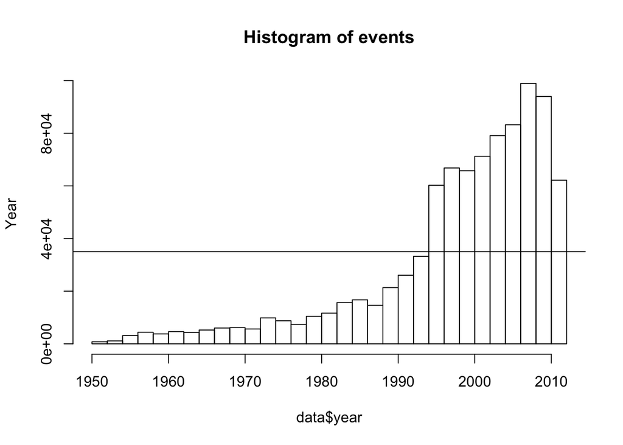

```r
data$year <- as.numeric(format(as.Date(data$BGN_DATE, format = "%m/%d/%Y %H:%M:%S"), "%Y"))
hist(data$year, breaks = 30, main="Histogram of events", ylab ="Year")
abline(h=3.5e+04)
```

It is evident from the histogram that from 1950-1995 there are less than 35K events per year. There is also a steep increase in events recorded by about 30K between 1995 and 1996. Further all years from 1996 have atleast 60K events recorded per year. So to reduce the bias in the data sample, extract data only from 1996-2011.

```r
data <- data[data$year>=1996,]
dim(data)
```

```
## [1] 653530     38
```

The new dataset is `72.4%` of the original dataset. Now examine the types of events.

```r
str(data$EVTYPE)
```

```
##  Factor w/ 985 levels "   HIGH SURF ADVISORY",..: 962 826 846 846 846 241 343 846 846 846 ...
```

```r
unique(data$EVTYPE)[1:10]
```

```
##  [1] WINTER STORM   TORNADO        TSTM WIND      HAIL
##  [5] HIGH WIND      HEAVY RAIN     FLASH FLOOD    FREEZING RAIN
##  [9] EXTREME COLD   EXCESSIVE HEAT
## 985 Levels:    HIGH SURF ADVISORY  COASTAL FLOOD ... wet micoburst
```

There are `985` unique types of events that impact public health and the economy.  
But there are only 48 event types strictly defined as per the `Storm Data Event Table` in page 6 of the document `[NWSI 10-1605 AUGUST 17, 2007]` https://d396qusza40orc.cloudfront.net/repdata%2Fpeer2_doc%2Fpd01016005curr.pdf We need to rectify the EVTYPE values. But this isn’t part of the scope for this project.

Now let’s proceed to find answers for the questions outlined in the synopsis.

**Across the US, which types of events are most harmful with respect to population health?**

Extract required columns and view the dataset

```r
#Extract only the columns that contain Events, No of Fatalities and Injuries
data1 <- subset(data, select=c(EVTYPE,FATALITIES,INJURIES))
str(data1)
```

```
## 'data.frame':    653530 obs. of  3 variables:
##  $ EVTYPE    : Factor w/ 985 levels "   HIGH SURF ADVISORY",..: 962 826 846 846 846 241 343 846 846 846 ...
##  $ FATALITIES: num  0 0 0 0 0 0 0 0 0 0 ...
##  $ INJURIES  : num  0 0 0 0 0 0 0 0 0 0 ...
```

```r
head(data1)
```

```
##              EVTYPE FATALITIES INJURIES
## 248768 WINTER STORM          0        0
## 248769      TORNADO          0        0
## 248770    TSTM WIND          0        0
## 248771    TSTM WIND          0        0
## 248772    TSTM WIND          0        0
## 248773         HAIL          0        0
```

The data is in good shape. Now let’s proceed.

```r
#Aggregate the Events by taking sum of columns for common Events
data1 <- aggregate(.~EVTYPE, data=data1, sum)
#Sort and Extract Top 15 Events
fatal <- data1[order(-data1$FATALITIES), ][1:15, 1:2]
injury <- data1[order(-data1$INJURIES), ][1:15, c(1,3)]
```

**Across the US, which types of events have the greatest economic consequences?**

```r
#Extract only the columns that contain Events, Crop and Property Damage Estimates
data2 <- data[,c('EVTYPE','CROPDMG','CROPDMGEXP','PROPDMG','PROPDMGEXP')]
str(data2)
```

```
## 'data.frame':    653530 obs. of  5 variables:
##  $ EVTYPE    : Factor w/ 985 levels "   HIGH SURF ADVISORY",..: 962 826 846 846 846 241 343 846 846 846 ...
##  $ CROPDMG   : num  38 0 0 0 0 0 0 0 0 0 ...
##  $ CROPDMGEXP: Factor w/ 9 levels "","0","2","?",..: 6 1 1 1 1 1 1 1 1 1 ...
##  $ PROPDMG   : num  380 100 3 5 2 0 400 12 8 12 ...
##  $ PROPDMGEXP: Factor w/ 19 levels "","+","-","0",..: 16 16 16 16 16 1 16 16 16 16 ...
```

```r
head(data2)
```

```
##              EVTYPE CROPDMG CROPDMGEXP PROPDMG PROPDMGEXP
## 248768 WINTER STORM      38          K     380          K
## 248769      TORNADO       0                100          K
## 248770    TSTM WIND       0                  3          K
## 248771    TSTM WIND       0                  5          K
## 248772    TSTM WIND       0                  2          K
## 248773         HAIL       0                  0
```

`CROPDMGEXP` and `PROPDMGEXP` are factors. Examine the levels of these factors.

```r
levels(data2$CROPDMGEXP)
```

```
## [1] ""  "0" "2" "?" "B" "K" "M" "k" "m"
```

```r
levels(data2$PROPDMGEXP)
```

```
##  [1] ""  "+" "-" "0" "1" "2" "3" "4" "5" "6" "7" "8" "?" "B" "H" "K" "M"
## [18] "h" "m"
```

```r
#Rename the factor Levels for the column containing Exponent data
levels(data2$CROPDMGEXP) <- c(0,1,100,0,1e+09,1e+03,1e+06,1e+03,1e+06)
levels(data2$PROPDMGEXP) <- c(0,0,0,1,10,100,1e+03,1e+04,1e+05,1e+06,1e+07,1e+08,0,1e+09,100,1e+03,1e+06,100,1e+06)
#Change Factor to Numeric Class for the columns with the Exponent data
data2$CROPDMGEXP <- as.numeric(levels(data2$CROPDMGEXP))[data2$CROPDMGEXP]
data2$PROPDMGEXP <- as.numeric(levels(data2$PROPDMGEXP))[data2$PROPDMGEXP]
#Create a new column which is the product of damage estimates and exponent
data2$CROPDMGVAL <- data2$CROPDMG * data2$CROPDMGEXP
data2$PROPDMGVAL <- data2$PROPDMG * data2$PROPDMGEXP
str(data2)
```

```
## 'data.frame':    653530 obs. of  7 variables:
##  $ EVTYPE    : Factor w/ 985 levels "   HIGH SURF ADVISORY",..: 962 826 846 846 846 241 343 846 846 846 ...
##  $ CROPDMG   : num  38 0 0 0 0 0 0 0 0 0 ...
##  $ CROPDMGEXP: num  1000 0 0 0 0 0 0 0 0 0 ...
##  $ PROPDMG   : num  380 100 3 5 2 0 400 12 8 12 ...
##  $ PROPDMGEXP: num  1000 1000 1000 1000 1000 0 1000 1000 1000 1000 ...
##  $ CROPDMGVAL: num  38000 0 0 0 0 0 0 0 0 0 ...
##  $ PROPDMGVAL: num  380000 100000 3000 5000 2000 0 400000 12000 8000 12000 ...
```

```r
head(data2)
```

```
##              EVTYPE CROPDMG CROPDMGEXP PROPDMG PROPDMGEXP CROPDMGVAL
## 248768 WINTER STORM      38       1000     380       1000      38000
## 248769      TORNADO       0          0     100       1000          0
## 248770    TSTM WIND       0          0       3       1000          0
## 248771    TSTM WIND       0          0       5       1000          0
## 248772    TSTM WIND       0          0       2       1000          0
## 248773         HAIL       0          0       0          0          0
##        PROPDMGVAL
## 248768     380000
## 248769     100000
## 248770       3000
## 248771       5000
## 248772       2000
## 248773          0
```

The data is in good shape. Now let’s proceed.

```r
#Extract the data that contains only the Events and the new Damage estimates
data3 <- subset(data2, select=c(EVTYPE,CROPDMGVAL,PROPDMGVAL))
#Aggregate the Events by taking sum of columns for common Events
data3 <- aggregate(.~EVTYPE, data=data3, sum)
#Sort and Extract Top 15 Events
crop <- data3[order(-data3$CROPDMGVAL), ][1:15, 1:2]
prop <- data3[order(-data3$PROPDMGVAL), ][1:15, c(1,3)]
```

## Results

**Across the US, which types of events are most harmful with respect to population health?**

```r
fatal
```

```
##                      EVTYPE FATALITIES
## 75           EXCESSIVE HEAT       1797
## 418                 TORNADO       1511
## 96              FLASH FLOOD        887
## 213               LIGHTNING        651
## 99                    FLOOD        414
## 287             RIP CURRENT        340
## 424               TSTM WIND        241
## 143                    HEAT        237
## 161               HIGH WIND        235
## 16                AVALANCHE        223
## 288            RIP CURRENTS        202
## 497            WINTER STORM        191
## 414       THUNDERSTORM WIND        130
## 82  EXTREME COLD/WIND CHILL        125
## 81             EXTREME COLD        113
```

```r
injury
```

```
##                EVTYPE INJURIES
## 418           TORNADO    20667
## 99              FLOOD     6758
## 75     EXCESSIVE HEAT     6391
## 213         LIGHTNING     4141
## 424         TSTM WIND     3629
## 96        FLASH FLOOD     1674
## 414 THUNDERSTORM WIND     1400
## 497      WINTER STORM     1292
## 167 HURRICANE/TYPHOON     1275
## 143              HEAT     1222
## 161         HIGH WIND     1083
## 488          WILDFIRE      911
## 139              HAIL      713
## 101               FOG      712
## 150        HEAVY SNOW      698
```

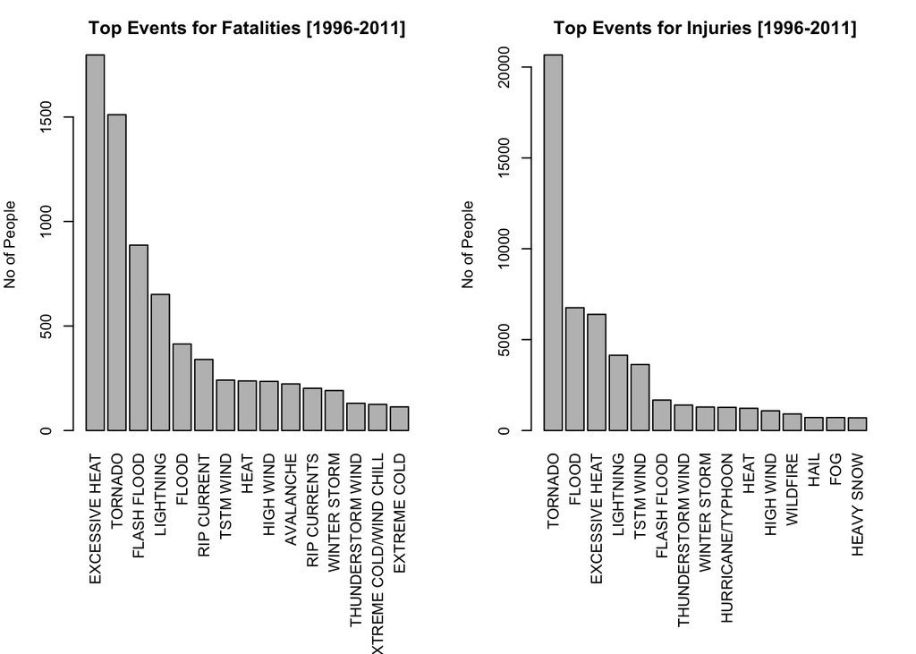

```r
#Plot the top 15 Events
par(mfrow = c(1, 2), mar = c(12, 4, 3, 2), cex = 0.7)
barplot(fatal$FATALITIES, las = 3, names.arg = fatal$EVTYPE, main = "Top Events for Fatalities [1996-2011]", ylab = "No of People")
barplot(injury$INJURIES, las = 3, names.arg = injury$EVTYPE, main = "Top Events for Injuries [1996-2011]", ylab = "No of People")
```

It is evident from the plot that the top events that cause fatalities and injury are different. `Excessive Heat` kills people more `(1797)` and `Tornado` causes injury to people more `(20667)` than any other event. But `Tornado` is also the second top most event that causes fatalities `(1511)`.

**Across the US, which types of events have the greatest economic consequences?**

```r
crop
```

```
##                EVTYPE  CROPDMGVAL
## 59            DROUGHT 13367566000
## 99              FLOOD  4974778400
## 166         HURRICANE  2741410000
## 167 HURRICANE/TYPHOON  2607872800
## 139              HAIL  2476029450
## 96        FLASH FLOOD  1334901700
## 81       EXTREME COLD  1288973000
## 108      FROST/FREEZE  1094086000
## 145        HEAVY RAIN   728169800
## 421    TROPICAL STORM   677711000
## 161         HIGH WIND   633561300
## 424         TSTM WIND   553915350
## 75     EXCESSIVE HEAT   492402000
## 414 THUNDERSTORM WIND   398331000
## 488          WILDFIRE   295472800
```

```r
prop
```

```
##                EVTYPE   PROPDMGVAL
## 99              FLOOD 143944833550
## 167 HURRICANE/TYPHOON  69305840000
## 328       STORM SURGE  43193536000
## 418           TORNADO  24616945710
## 96        FLASH FLOOD  15222203910
## 139              HAIL  14595143420
## 166         HURRICANE  11812819010
## 421    TROPICAL STORM   7642475550
## 161         HIGH WIND   5247860360
## 488          WILDFIRE   4758667000
## 329  STORM SURGE/TIDE   4641188000
## 424         TSTM WIND   4478026440
## 191         ICE STORM   3642248810
## 414 THUNDERSTORM WIND   3382654440
## 487  WILD/FOREST FIRE   3001782500
```

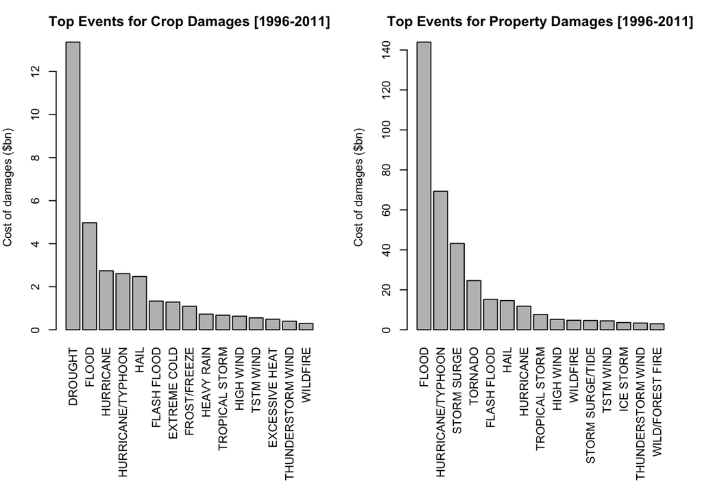

```r
#Plot the Top 15 Events
par(mfrow = c(1, 2), mar = c(12, 4, 3, 2), cex = 0.7)
barplot(crop$CROPDMGVAL/(10^9), las = 3, names.arg = crop$EVTYPE, main = "Top Events for Crop Damages [1996-2011]", ylab = "Cost of damages ($bn)")
barplot(prop$PROPDMGVAL/(10^9), las = 3, names.arg = prop$EVTYPE, main = "Top Events for Property Damages [1996-2011]", ylab = "Cost of damages ($bn)")
```

It is evident from the plot that the top events that cause greatest crop and property damage are different. `Drought` damages crops more `(US$ 13.3bn)` and `Flood` damages properties more `(US$ 143bn)` than any other event. But events like `Drought`, `Excessive Heat`, `Extreme Cold`, etc are unique only to crop damages. So excluding them means that the top two events for both crop and property damages are the same - `Flood` and `Hurricane`.